# TRATAMIENTO DE DATOS CON R

Joaquín Planelles Romero e Isabel Padilla Sánchez

octubre de 2021

# **Funciones de sumarización**

Como hemos visto, los tres pilares fundamentales en el tratamiento de datos con dplyr son el tratamiento de filas, de las columnas y las funciones de sumarización. Estas últimas son las que nos van a ocupar en esta parte de la unidad.  
Con las funciones de sumarización construimos **estadísticos** que resumen un conjunto de valores/observaciones en un único valor. Ejemplos de estos estadísticos son: la media, la conteo de casos o la suma de los factores de elevación por ejemplo.  
Los principales comandos para resumir datos son `summarise()` y `group_by()`. Con summarise se crea un nuevo marco de datos con una fila que resume todas las observaciones de entrada. Si además lo combinamos con group_by, se tendrá una columna para cada variable de agrupación y tantas filas como combinaciones existan de las categorías de las variables de agrupación.

[figure not shown]

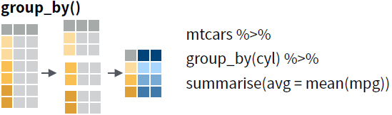

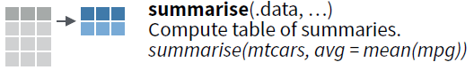

Además existen una serie de funciones que trabajan conjuntamente con `summarise()`. Algunas de ellas pertenecen al paquete **base** y otras a **dplyr**. Esta es otra ventaja de esta filosofía de trabajo, las funciones de dplyr también entienden a las funciones del paquete base y se pueden utilizar de forma conjunta.

Las siguiente funciones toman como argumento un vector y devuelven un único resultado.

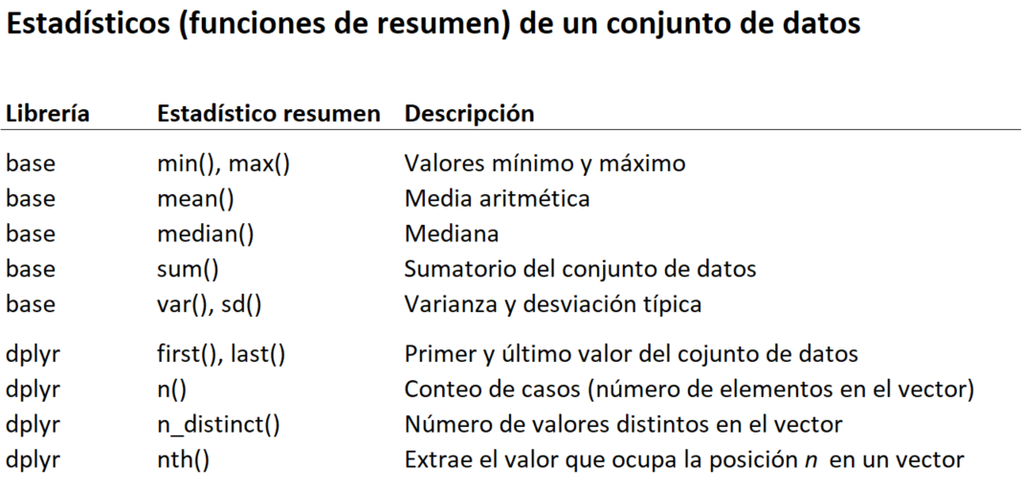

Veamos algún ejemplo para entender mejor cómo funcionan estos comandos y cómo se construyen las sentencias. Para ello vamos a utilizar el fichero **encuesta** de la librería **datos**. El fichero encuesta contiene información individual procedente de la Encuesta Social General de EE.UU. Para cada individuo disponemos de información básica como el año de la encuesta, estado civil, edad, raza… podemos explorar el fichero escribiendo en la consola `?encuesta` después de haber ejecutado `library(datos)`. Aparecerá la ayuda con la información.

El objetivo en este ejemplo es tratar de encontrar cuántas personas hay en el fichero.

```r
Ejemplo <- encuesta %>% summarise(Personas = n())
Ejemplo
```

```
## # A tibble: 1 x 1
##   Personas
##      <int>
## 1    21483
```

El resultado es un valor con el número de casos que hay en el tibble y aparece en una columna que hemos denominado ‘Personas’.

Por otro lado si queremos ver el número de personas según el estado civil, tendríamos que agrupar por las categorías de dicha columna y aquí se obtendría el número de personas que hay por cada categoría.

```r
Ejemplo <- encuesta %>% group_by(estado_civil) %>% summarise(Personas = n())
Ejemplo
```

```
## # A tibble: 6 x 2
##   estado_civil       Personas
##   <fct>                 <int>
## 1 Sin respuesta            17
## 2 Nunca se ha casado     5416
## 3 Separado                743
## 4 Divorciado             3383
## 5 Viudo                  1807
## 6 Casado                10117
```

En este ejemplo dentro del summarise se ha aplicado la función `n()` que como hemos visto nos devuelve el número de valores de un vector. Si quisiéramos además calcular edad media según el estado civil, la línea de comandos sería la siguiente:

```r
Ejemplo <- encuesta %>% group_by(estado_civil) %>% summarise(Personas = n(), edad_media = mean(as.numeric(edad),na.rm = TRUE))
Ejemplo
```

```
## # A tibble: 6 x 3
##   estado_civil       Personas edad_media
##   <fct>                 <int>      <dbl>
## 1 Sin respuesta            17       52.4
## 2 Nunca se ha casado     5416       33.9
## 3 Separado                743       45.3
## 4 Divorciado             3383       51.1
## 5 Viudo                  1807       71.7
## 6 Casado                10117       48.7
```

**¡¡¡OJO!!!** Aquí hay que tener en cuenta dos cosas:

**1)** Para usar algunas funciones es necesario que el tipo de dato de la variable sea **numérico**.

**2)** Cuando en la columna tenemos algunos **registros vacíos** (son NA) tenemos que introducir en la función el argumento `na.rm = TRUE` como hemos hecho con `mean()`. Esto hace que no tenga en cuenta esos valores NA y calcule la media en caso contrario, no hace el cálculo.

# Preguntas de auto-evaluación

El objetivo de las siguientes preguntas es que podáis auto-evaluar si habéis adquirido los conocimientos. Encontraréis las respuestas en la pestaña de soluciones.

Para la resolución de algunos de estos ejercicios es necesario utilizar los ficheros planos del censo de 2011 que os hemos facilitado.

- **Pregunta 1**. ¿Supongamos que tenemos un fichero con datos de personas donde algunas de las variables que contiene son la edad y el sexo. ¿Qué combinación de comandos utilizarías para obtener la edad mínima por sexo?
  1. group_by()-summarise()-n()
  2. select() -summarise()-min()
  3. group_by()-summarise()-min()
  4. select() -group_by() -n()
- **Pregunta 2**. Del fichero **nombres** de la `librería datos` que hace referencia los nombres de recién nacidos. Averigua a cuántas personas les pusieron el nombre de Shakira desde 2010 (este incluido).
  1. 488
  2. 48
  3. 363
  4. 633
- **Pregunta 3**. En el fichero **nombres**, para cada año y por sexo, calcula cuáles son los nombres más frecuentes y sobre el data.frame obtenido, indica cuál fue el nombre femenino más puesto en 1880 y el nombre masculino con mayor frecuencia en 2017.
  1. Emma y Lian
  2. Mary y John
  3. Mary y Liam
  4. Pepa y Pepe
- **Pregunta 4**. Del fichero que tiene datos de las **olimpiadas** indica cuáles son las edades de los participantes más jóvenes de los dos últimas ediciones (olimpiadas de invierno de 2014 y las olimpiadas de Río 2016).
  1. 14 y 12
  2. 13 y 14
  3. 13 y 15
  4. 12 y 15
- **Pregunta 5**. Con los datos del **Censo 2011** calcula el porcentaje de población de cada provincia de Andalucía. ¿Qué porcentaje representa la población de Granada?
  1. 11.0 %
  2. 14.2 %
  3. 7.9 %
  4. 9.7 %

# Soluciones

A continuación se muestran, marcadas y en rojo, las soluciones a las preguntas de auto-evaluación

- **Pregunta 1**. ¿Supongamos que tenemos un fichero con datos de personas donde algunas de las variables que contiene son la edad y el sexo. ¿Qué combinación de comandos utilizarías para obtener la edad mínima por sexo?
  1. group_by()-summarise()-n()
  2. select() -summarise()-min()
  3. **group_by() -summarise()-min()**
  4. select() -group_by()-n()

  **En concreto, un código válido para obtener el resultado:**

  ```r
  P1 <- datos %>% group_by(sexo) %>% summarise(edad_min = min(edad))
  ```

- **Pregunta 2**. Del fichero **nombres** de la `librería datos` que hace referencia los nombres de recién nacidos. Averigua a cuántas personas les pusieron el nombre de Shakira desde 2010 (este incluido).
  1. **488**
  2. 48
  3. 363
  4. 633

  **En concreto, hemos utilizado el siguiente código para obtener el resultado:**

  ```r
  library(datos)
  P2 <- nombres %>% filter(nombre=='Shakira' & anio>=2010) %>% summarise(total=sum(n))
  ```

- **Pregunta 3**. En el fichero **nombres**, para cada año y por sexo, calcula cuáles son los nombres más frecuentes y sobre el data.frame obtenido, indica cuál fue el nombre femenino más puesto en 1880 y el nombre masculino con mayor frecuencia en 2017.
  1. Emma y Lian
  2. Mary y John
  3. **Mary y Liam**
  4. Pepa y Pepe

  **En concreto, hemos utilizado el siguiente código para obtener el resultado:**

  ```r
  library(datos)
  P3 <- nombres %>% group_by(anio,sexo) %>% filter(n==max(n))
  ```

- **Pregunta 4**. Del fichero que tiene datos de las **olimpiadas** indica cuáles son las edades de los participantes más jóvenes de los dos últimas ediciones (olimpiadas de invierno de 2014 y las olimpiadas de Río 2016).
  1. 14 y 12
  2. 13 y 14
  3. **13 y 15**
  4. 12 y 15

  **En concreto, hemos utilizado el siguiente código para obtener el resultado:**

  ```r
  P4 <- olympics %>% group_by(games) %>% summarise(joven = min(age,na.rm = TRUE))
  ```

- **Pregunta 5**. Con los datos del **Censo 2011** calcula el porcentaje de población de cada provincia de Andalucía. ¿Qué porcentaje representa la población de Granada?
  1. **11.0%**
  2. 14.2 %
  3. 7.9 %
  4. 9.7 %

  **En concreto, hemos utilizado el siguiente código para obtener el resultado:**

  ```r
  P5 <- DATOS_HP %>% group_by(CPRO) %>% summarise(Pob=sum(FACTOR)) %>% mutate(pct=Pob/sum(Pob)*100)
  ```